# Introduction to Data Visualization with Seaborn

```python
# Import libraraies
import pandas as pd
import matplotlib.pyplot as plt
import seaborn as sns
```

```python
countries = pd.read_csv('countries-of-the-world.csv')
countries.head()
```

|  | Country | Region | Population | Area (sq. mi.) | Pop. Density (per sq. mi.) | Coastline (coast/area ratio) | Net migration | Infant mortality (per 1000 births) | GDP ($ per capita) | Literacy (%) | Phones (per 1000) | Arable (%) | Crops (%) | Other (%) | Climate | Birthrate | Deathrate | Agriculture | Industry | Service |
| --- | --- | --- | --- | --- | --- | --- | --- | --- | --- | --- | --- | --- | --- | --- | --- | --- | --- | --- | --- | --- |
| 0 | Afghanistan | ASIA (EX. NEAR EAST) | 31056997 | 647500 | 48,0 | 0,00 | 23,06 | 163,07 | 700.0 | 36,0 | 3,2 | 12,13 | 0,22 | 87,65 | 1 | 46,6 | 20,34 | 0,38 | 0,24 | 0,38 |
| 1 | Albania | EASTERN EUROPE | 3581655 | 28748 | 124,6 | 1,26 | -4,93 | 21,52 | 4500.0 | 86,5 | 71,2 | 21,09 | 4,42 | 74,49 | 3 | 15,11 | 5,22 | 0,232 | 0,188 | 0,579 |
| 2 | Algeria | NORTHERN AFRICA | 32930091 | 2381740 | 13,8 | 0,04 | -0,39 | 31 | 6000.0 | 70,0 | 78,1 | 3,22 | 0,25 | 96,53 | 1 | 17,14 | 4,61 | 0,101 | 0,6 | 0,298 |
| 3 | American Samoa | OCEANIA | 57794 | 199 | 290,4 | 58,29 | -20,71 | 9,27 | 8000.0 | 97,0 | 259,5 | 10 | 15 | 75 | 2 | 22,46 | 3,27 | NaN | NaN | NaN |
| 4 | Andorra | WESTERN EUROPE | 71201 | 468 | 152,1 | 0,00 | 6,6 | 4,05 | 19000.0 | 100,0 | 497,2 | 2,22 | 0 | 97,78 | 3 | 8,71 | 6,25 | NaN | NaN | NaN |

```python
countries.dropna(inplace= True)
countries['Phones (per 1000)'] = countries['Phones (per 1000)'].str.replace(',', '.')
```

```python
gdp = countries['GDP ($ per capita)']  # a list contains the value of GDP per country
phones = countries['Phones (per 1000)']  # a list of the number of mobile phones per 1,000 people in that country
percent_literate = countries['Literacy (%)']  # a list that contains the percent of each country's population that can read and write
```

### Making a scatter plot with a list

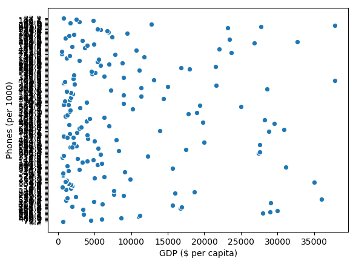

```python
# Create scatter plot with GDP on the x-axis and number of phones on the y-axis
sns.scatterplot(x=gdp, y=phones)

# Show plot
plt.show()
```

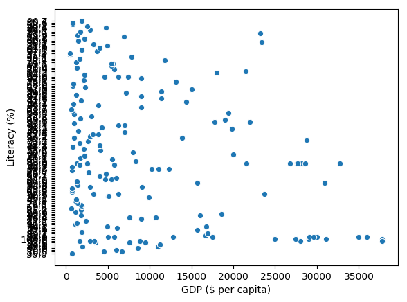

```python
# Change this scatter plot to have percent literate on the y-axis
sns.scatterplot(x=gdp, y=percent_literate)

# Show plot
plt.show()
```

### Making a count plot with a list

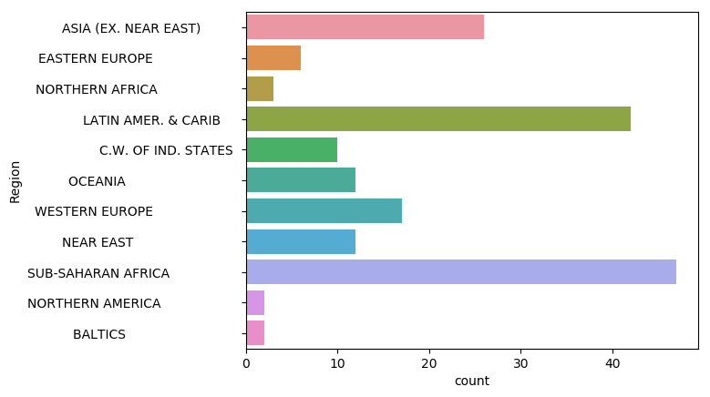

```python
region = countries['Region']
# Create count plot with region on the y-axis
sns.countplot(y=region)

# Show plot
plt.show()
```

### Making a count plot with a DataFrame

```python
df = pd.read_csv('young-people-survey-responses.csv')
df.head()
```

|  | Unnamed: 0 | Music | Techno | Movies | History | Mathematics | Pets | Spiders | Loneliness | Parents' advice | Internet usage | Finances | Age | Siblings | Gender | Village - town |
| --- | --- | --- | --- | --- | --- | --- | --- | --- | --- | --- | --- | --- | --- | --- | --- | --- |
| 0 | 0 | 5.0 | 1.0 | 5.0 | 1.0 | 3.0 | 4.0 | 1.0 | 3.0 | 4.0 | few hours a day | 3.0 | 20.0 | 1.0 | female | village |
| 1 | 1 | 4.0 | 1.0 | 5.0 | 1.0 | 5.0 | 5.0 | 1.0 | 2.0 | 2.0 | few hours a day | 3.0 | 19.0 | 2.0 | female | city |
| 2 | 2 | 5.0 | 1.0 | 5.0 | 1.0 | 5.0 | 5.0 | 1.0 | 5.0 | 3.0 | few hours a day | 2.0 | 20.0 | 2.0 | female | city |
| 3 | 3 | 5.0 | 2.0 | 5.0 | 4.0 | 4.0 | 1.0 | 5.0 | 5.0 | 2.0 | most of the day | 2.0 | 22.0 | 1.0 | female | city |
| 4 | 4 | 5.0 | 2.0 | 5.0 | 3.0 | 2.0 | 1.0 | 1.0 | 3.0 | 3.0 | few hours a day | 4.0 | 20.0 | 1.0 | female | village |

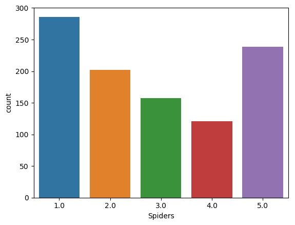

```python
# Create a count plot with "Spiders" on the x-axis
sns.countplot(x='Spiders', data=df)

# Display the plot
plt.show()
```

### Hue and scatter plots

```python
student_data = pd.read_csv('student-alcohol-consumption.csv')
student_data.head()
```

|  | Unnamed: 0 | school | sex | age | famsize | Pstatus | Medu | Fedu | traveltime | failures | ... | goout | Dalc | Walc | health | absences | G1 | G2 | G3 | location | study_time |
| --- | --- | --- | --- | --- | --- | --- | --- | --- | --- | --- | --- | --- | --- | --- | --- | --- | --- | --- | --- | --- | --- |
| 0 | 0 | GP | F | 18 | GT3 | A | 4 | 4 | 2 | 0 | ... | 4 | 1 | 1 | 3 | 6 | 5 | 6 | 6 | Urban | 2 to 5 hours |
| 1 | 1 | GP | F | 17 | GT3 | T | 1 | 1 | 1 | 0 | ... | 3 | 1 | 1 | 3 | 4 | 5 | 5 | 6 | Urban | 2 to 5 hours |
| 2 | 2 | GP | F | 15 | LE3 | T | 1 | 1 | 1 | 3 | ... | 2 | 2 | 3 | 3 | 10 | 7 | 8 | 10 | Urban | 2 to 5 hours |
| 3 | 3 | GP | F | 15 | GT3 | T | 4 | 2 | 1 | 0 | ... | 2 | 1 | 1 | 5 | 2 | 15 | 14 | 15 | Urban | 5 to 10 hours |
| 4 | 4 | GP | F | 16 | GT3 | T | 3 | 3 | 1 | 0 | ... | 2 | 1 | 2 | 5 | 4 | 6 | 10 | 10 | Urban | 2 to 5 hours |

5 rows × 30 columns

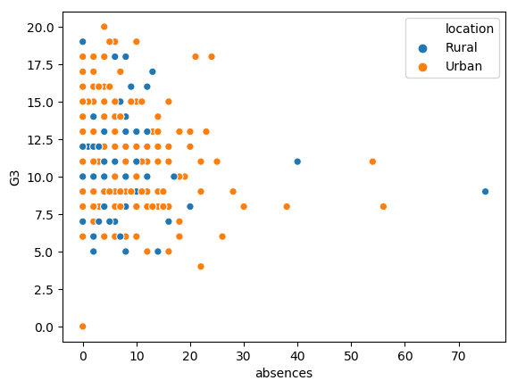

```python
# Change the legend order in the scatter plot
sns.scatterplot(x="absences", y="G3",
                data=student_data,
                hue="location", hue_order=['Rural', 'Urban'])

# Show plot
plt.show()
```

### Hue and count plots

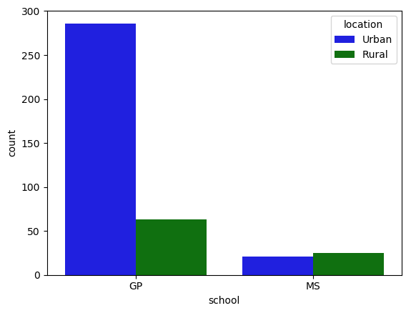

```python
# Create a dictionary mapping subgroup values to colors
palette_colors = {'Rural': "green", 'Urban': "blue"}

# Create a count plot of school with location subgroups
sns.countplot(x="school", data=student_data, hue='location', palette=palette_colors)

# Display plot
plt.show()
```

### Creating subplots with col and row

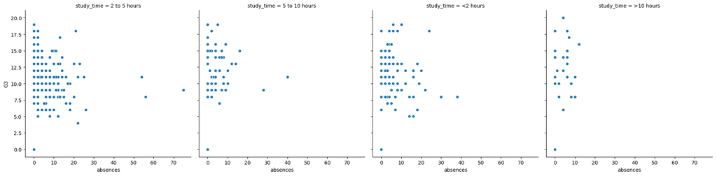

```python
# Change to make subplots based on study time
sns.relplot(x="absences", y="G3",
            data=student_data,
            kind="scatter", col='study_time')

# Show plot
plt.show()
```

### Creating two-factor subplots

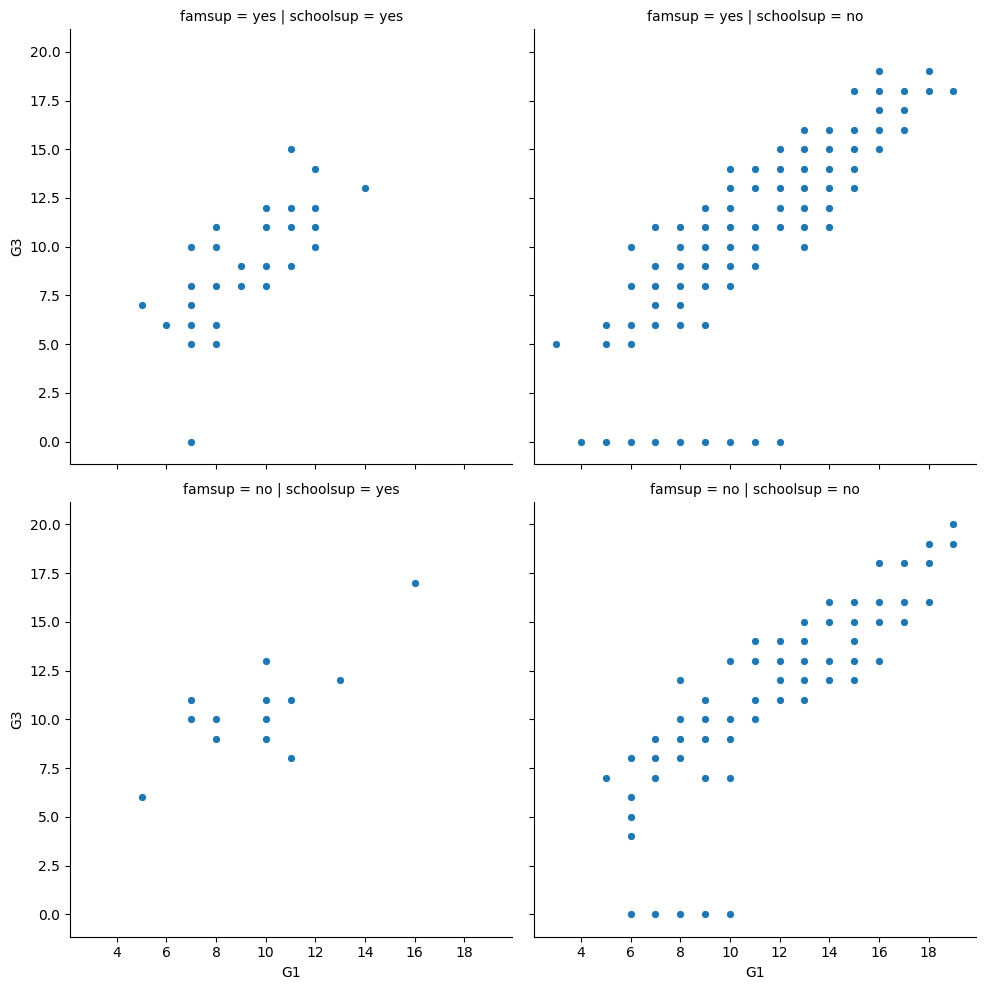

```python
# Adjust further to add subplots based on family support
sns.relplot(x="G1", y="G3",
            data=student_data,
            kind="scatter",
            col="schoolsup", col_order=["yes", "no"],
            row='famsup', row_order=['yes','no'])

# Show plot
plt.show()
```

### Changing the size of scatter plot points

```python
mpg = pd.read_csv('mpg.csv')
mpg.head()
```

|  | mpg | cylinders | displacement | horsepower | weight | acceleration | model_year | origin | name |
| --- | --- | --- | --- | --- | --- | --- | --- | --- | --- |
| 0 | 18.0 | 8 | 307.0 | 130.0 | 3504 | 12.0 | 70 | usa | chevrolet chevelle malibu |
| 1 | 15.0 | 8 | 350.0 | 165.0 | 3693 | 11.5 | 70 | usa | buick skylark 320 |
| 2 | 18.0 | 8 | 318.0 | 150.0 | 3436 | 11.0 | 70 | usa | plymouth satellite |
| 3 | 16.0 | 8 | 304.0 | 150.0 | 3433 | 12.0 | 70 | usa | amc rebel sst |
| 4 | 17.0 | 8 | 302.0 | 140.0 | 3449 | 10.5 | 70 | usa | ford torino |

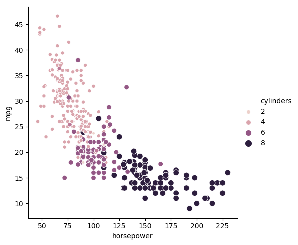

```python
# Create scatter plot of horsepower vs. mpg
sns.relplot(x="horsepower", y="mpg",
            data=mpg, kind="scatter",
            size="cylinders", hue='cylinders')

# Show plot
plt.show()
```

Cars with higher horsepower tend to get a lower number of miles per gallon. They also tend to have a higher number of cylinders

### Changing the style of scatter plot points

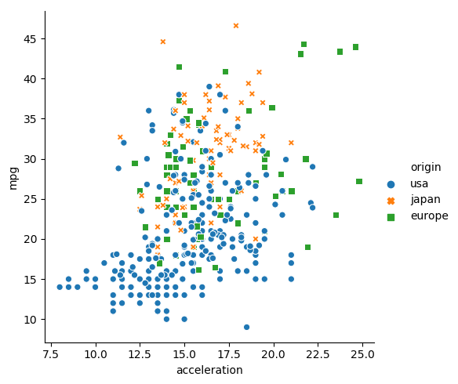

```python
# Create a scatter plot of acceleration vs. mpg
sns.relplot(x='acceleration', y='mpg', data=mpg, kind='scatter', hue='origin', style='origin')

# Show plot
plt.show()
```

Cars from the USA tend to accelerate more quickly and get lower miles per gallon compared to cars from Europe and Japan.

### Interpreting line plots

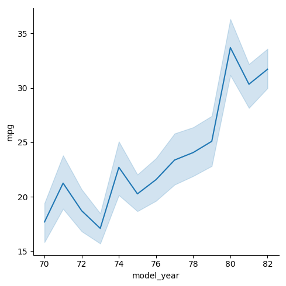

```python
# Create line plot
sns.relplot(x='model_year', y='mpg', data=mpg, kind='line')

# Show plot
plt.show()
```

The shaded region represents a confidence interval for the mean, not the distribution of the observations

### Visualizing standard deviation with line plots

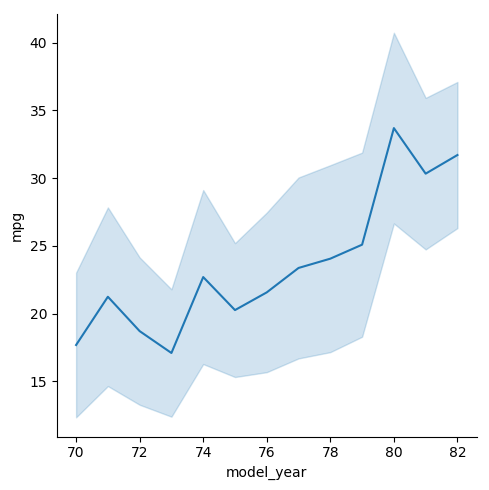

```python
# Make the shaded area show the standard deviation
sns.relplot(x="model_year", y="mpg",
            data=mpg, kind="line", ci='sd')

# Show plot
plt.show()
```

### Plotting subgroups in line plots

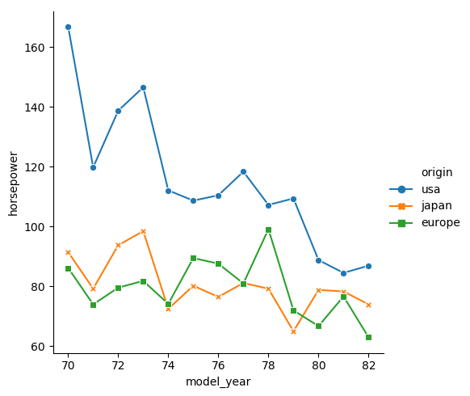

```python
# Change to create subgroups for country of origin
# Add markers and make each line have the same style
sns.relplot(x="model_year", y="horsepower",
            data=mpg, kind="line",
            ci=None, style="origin",
            hue="origin", markers=True, dashes=False)

# Show plot
plt.show()
```

### Count plots

```python
survey_data = pd.read_csv('young-people-survey-responses.csv')
survey_data.head()
```

|  | Unnamed: 0 | Music | Techno | Movies | History | Mathematics | Pets | Spiders | Loneliness | Parents' advice | Internet usage | Finances | Age | Siblings | Gender | Village - town |
| --- | --- | --- | --- | --- | --- | --- | --- | --- | --- | --- | --- | --- | --- | --- | --- | --- |
| 0 | 0 | 5.0 | 1.0 | 5.0 | 1.0 | 3.0 | 4.0 | 1.0 | 3.0 | 4.0 | few hours a day | 3.0 | 20.0 | 1.0 | female | village |
| 1 | 1 | 4.0 | 1.0 | 5.0 | 1.0 | 5.0 | 5.0 | 1.0 | 2.0 | 2.0 | few hours a day | 3.0 | 19.0 | 2.0 | female | city |
| 2 | 2 | 5.0 | 1.0 | 5.0 | 1.0 | 5.0 | 5.0 | 1.0 | 5.0 | 3.0 | few hours a day | 2.0 | 20.0 | 2.0 | female | city |
| 3 | 3 | 5.0 | 2.0 | 5.0 | 4.0 | 4.0 | 1.0 | 5.0 | 5.0 | 2.0 | most of the day | 2.0 | 22.0 | 1.0 | female | city |
| 4 | 4 | 5.0 | 2.0 | 5.0 | 3.0 | 2.0 | 1.0 | 1.0 | 3.0 | 3.0 | few hours a day | 4.0 | 20.0 | 1.0 | female | village |

```python
survey_data['Age Category'] = ['less than 21' if age < 21 else '+21' for age in survey_data['Age']]
survey_data['Interested in Math'] = [True if math > 3 else False for math in survey_data['Mathematics']]
```

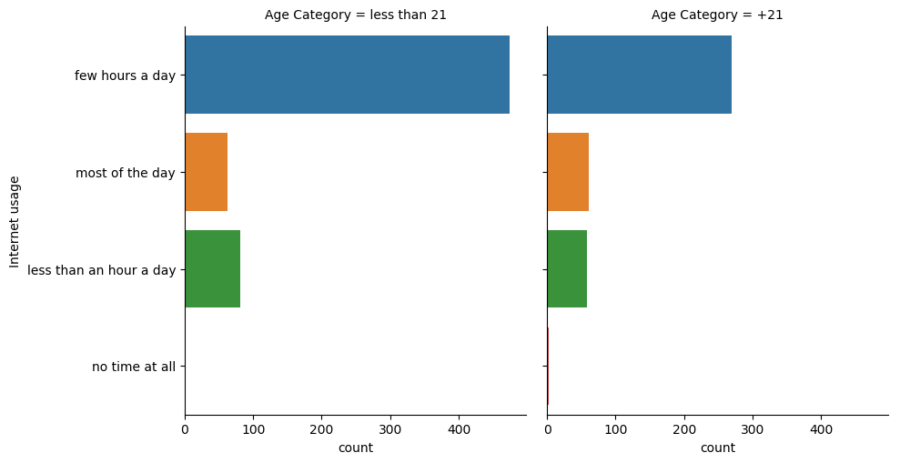

```python
# Create column subplots based on age category
sns.catplot(y="Internet usage", data=survey_data,
            kind="count", col='Age Category')

# Show plot
plt.show()
```

### Bar plots with percentages

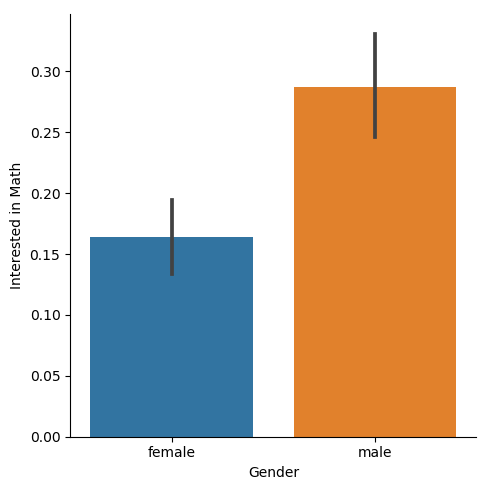

```python
# Create a bar plot of interest in math, separated by gender
sns.catplot(x='Gender', y="Interested in Math", data=survey_data, kind='bar')

# Show plot
plt.show()
```

When the y-variable is True/False, bar plots will show the percentage of responses reporting True. This plot shows us that males report a much higher interest in math compared to females.

### Customizing bar plots

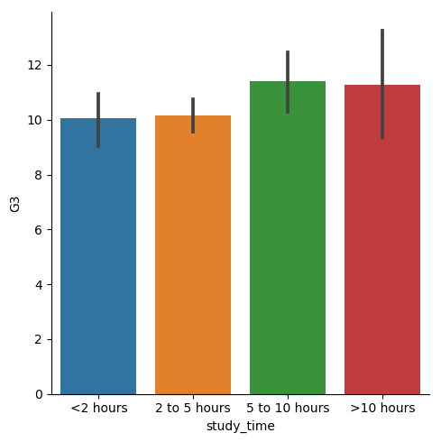

```python
# Rearrange the categories
sns.catplot(x="study_time", y="G3",
            data=student_data,
            kind="bar", order=['<2 hours', '2 to 5 hours', '5 to 10 hours', '>10 hours'])

# Show plot
plt.show()
```

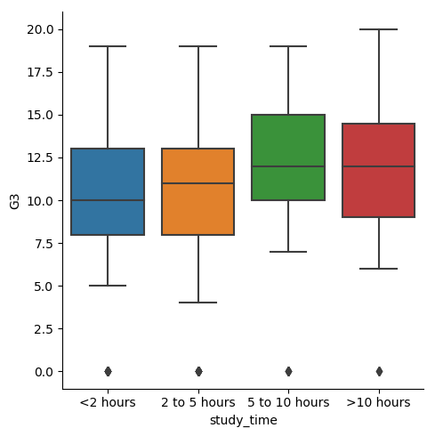

```python
# Specify the category ordering
study_time_order = ["<2 hours", "2 to 5 hours",
                    "5 to 10 hours", ">10 hours"]

# Create a box plot and set the order of the categories
sns.catplot(x='study_time', y='G3', data=student_data, kind='box', order=study_time_order)

# Show plot
plt.show()
```

### Omitting outliers

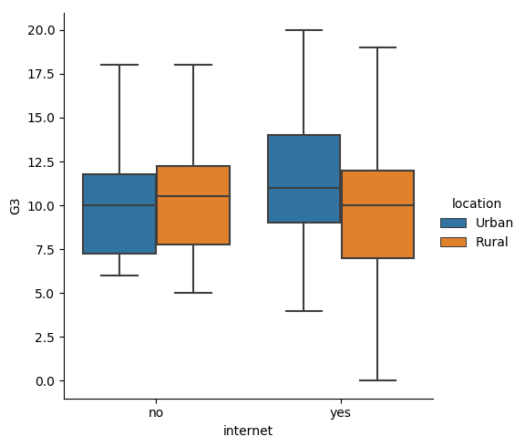

```python
# Create a box plot with subgroups and omit the outliers
sns.catplot(x='internet', y='G3', data=student_data, kind='box', hue='location', sym='')

# Show plot
plt.show()
```

### Adjusting the whiskers

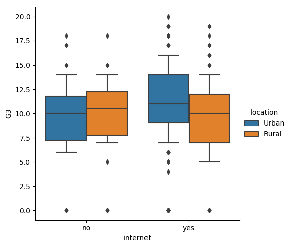

```python
# Set the whiskers to 0.5 * IQR
sns.catplot(x="internet", y="G3",
            data=student_data,
            kind="box", hue='location', whis=.5)

# Show plot
plt.show()
```

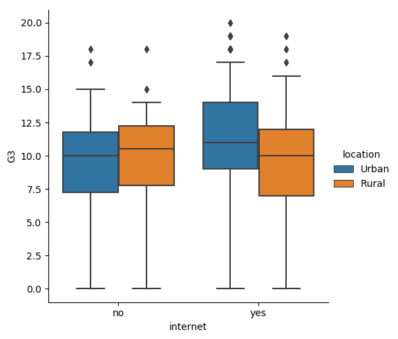

```python
# Extend the whiskers to the 5th and 95th percentile
sns.catplot(x="internet", y="G3",
            data=student_data,
            kind="box", hue='location', whis=[5,95])

# Show plot
plt.show()
```

### Customizing point plots

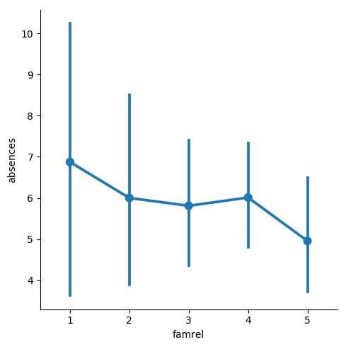

```python
# Create a point plot of family relationship vs. absences
sns.catplot(x='famrel', y='absences', data=student_data, kind='point')

# Show plot
plt.show()
```

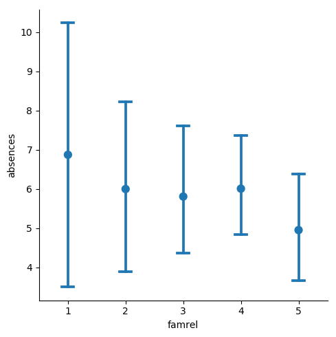

```python
# Remove the lines joining the points
sns.catplot(x="famrel", y="absences",
			data=student_data,
            kind="point",
            capsize=0.2, join=False)

# Show plot
plt.show()
```

While the average number of absences is slightly smaller among students with higher-quality family relationships, the large confidence intervals tell us that we can't be sure there is an actual association here.

### Point plots with subgroups

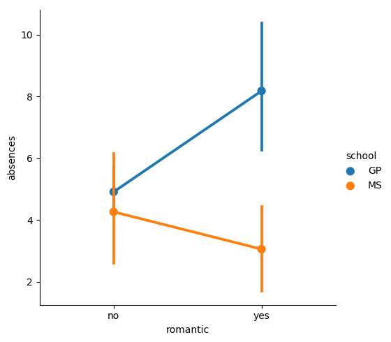

```python
# Create a point plot with subgroups
sns.catplot(x='romantic', y='absences', data=student_data, hue='school', kind='point')

# Show plot
plt.show()
```

### use median as estimator instead of mean

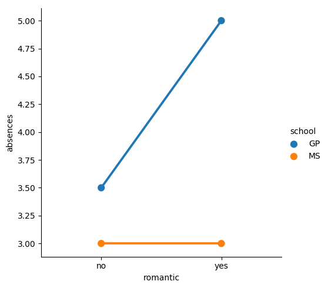

```python
# Import median function from numpy
from numpy import median

# Plot the median number of absences instead of the mean
sns.catplot(x="romantic", y="absences",
			data=student_data,
            kind="point",
            hue="school",
            ci=None, estimator=median)

# Show plot
plt.show()
```

It looks like students in romantic relationships have a higher average and median number of absences in the GP school, but this association does not hold for the MS school

### Changing style and palette

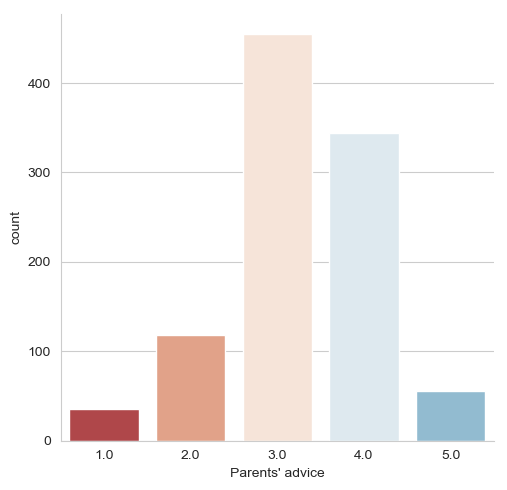

```python
# Set the style to "whitegrid"
sns.set_style('whitegrid')

# Change the color palette to "RdBu"
sns.set_palette("RdBu")

sns.catplot(x="Parents' advice",
            data=survey_data,
            kind="count")

# Show plot
plt.show()
```

### Changing the scale

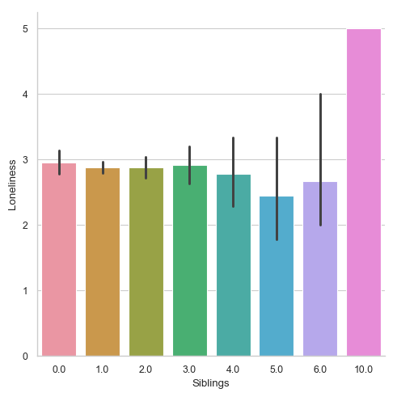

```python
# Set the context to "paper"
sns.set_context('paper')

# Create bar plot
sns.catplot(x="Siblings", y="Loneliness",
            data=survey_data, kind="bar")

# Show plot
plt.show()
```

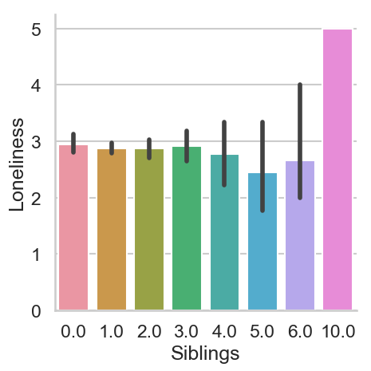

```python
# Set the context to "talk"
sns.set_context('talk')   # paper(default), notebook, talk, poster

# Create bar plot
sns.catplot(x="Siblings", y="Loneliness",
            data=survey_data, kind="bar")

# Show plot
plt.show()
```

### Using a custom palette

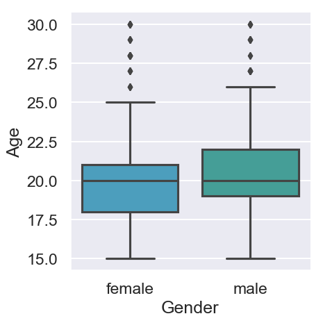

```python
# Set the style to "darkgrid"
sns.set_style('darkgrid')

# Set a custom color palette
sns.set_palette(["#39A7D0", "#36ADA4"])

# Create the box plot of age distribution by gender
sns.catplot(x="Gender", y="Age",
            data=survey_data, kind="box")

# Show plot
plt.show()
```

### Adding a title to a FacetGrid object (relplot, catplot)

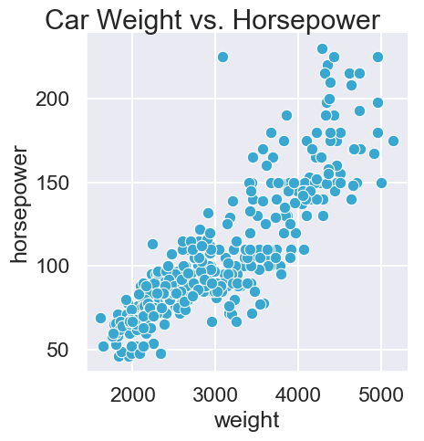

```python
# Create scatter plot
g = sns.relplot(x="weight",
                y="horsepower",
                data=mpg,
                kind="scatter")

# Add a title "Car Weight vs. Horsepower"
g.fig.suptitle("Car Weight vs. Horsepower")

# Show plot
plt.show()
```